# ReneWind

## Model Building with Original data

**Let's start by building different models using KFold and cross_val_score**

- Stratified K-Folds cross-validation provides dataset indices to split data into train/validation sets. Split dataset into k consecutive folds (without shuffling by default) keeping the distribution of both classes in each fold the same as the target variable. Each fold is then used once as validation while the k - 1 remaining folds form the training set.

```python
models = []  # Empty list to store all the models

# Appending models into the list
models.append(("lr", LogisticRegression(random_state=1)))
models.append(("Bagging", BaggingClassifier(random_state=1)))
models.append(("Random forest", RandomForestClassifier(random_state=1)))
models.append(("GBM", GradientBoostingClassifier(random_state=1)))
models.append(("Adaboost", AdaBoostClassifier(random_state=1)))
models.append(("dtree", DecisionTreeClassifier(random_state=1)))

results = []  # Empty list to store all model's CV scores
names = []  # Empty list to store name of the models


# loop through all models to get the mean cross validated score
print("\n" "Cross-Validation Performance:" "\n")

for name, model in models:
    scoring = scorer
    kfold = StratifiedKFold(
        n_splits=5, shuffle=True, random_state=1
    )  # Setting number of splits equal to 5
    cv_result = cross_val_score(
        estimator=model, X=X_train, y=y_train, scoring=scoring, cv=kfold
    )
    results.append(cv_result)
    names.append(name)
    print("{}: {}".format(name, cv_result.mean() * 100))

print("\n" "Training Performance:" "\n")

for name, model in models:
    model.fit(X_train, y_train)
    scores = Minimum_Vs_Model_cost(y_train, model.predict(X_train)) * 100
    print("{}: {}".format(name, scores))
```

```
Cross-Validation Performance:

lr: 52.948994378378856
Bagging: 68.86574469253958
Random forest: 71.52966747632996
GBM: 67.35879816374911
Adaboost: 59.88430481901255
dtree: 65.12035300489133

Training Performance:

lr: 53.03438611620136
Bagging: 91.43281917859134
Random forest: 100.0
GBM: 72.94292068198665
Adaboost: 61.3160518444666
dtree: 100.0
```

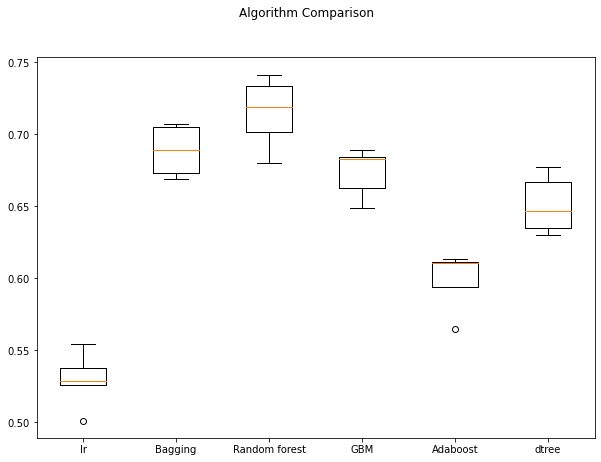

```python
# Plotting boxplots for CV scores of all models defined above
fig = plt.figure(figsize=(10, 7))

fig.suptitle("Algorithm Comparison")
ax = fig.add_subplot(111)

plt.boxplot(results)
ax.set_xticklabels(names)

plt.show()
```

```python
# Calculating different metrics on train set
print("Training performance:")
for name, model in models:
    model_train_perf = model_performance_classification_sklearn(model, X_train, y_train)
    print("{}:\n {}".format(name, model_train_perf))
```

```
Training performance:
lr:
    Accuracy  Recall  Precision    F1  Minimum_Vs_Model_cost
0     0.967   0.485      0.853 0.619                  0.530
Bagging:
    Accuracy  Recall  Precision    F1  Minimum_Vs_Model_cost
0     0.997   0.944      0.999 0.971                  0.914
Random forest:
    Accuracy  Recall  Precision    F1  Minimum_Vs_Model_cost
0     1.000   1.000      1.000 1.000                  1.000
GBM:
    Accuracy  Recall  Precision    F1  Minimum_Vs_Model_cost
0     0.987   0.780      0.981 0.869                  0.729
Adaboost:
    Accuracy  Recall  Precision    F1  Minimum_Vs_Model_cost
0     0.976   0.637      0.890 0.743                  0.613
dtree:
    Accuracy  Recall  Precision    F1  Minimum_Vs_Model_cost
0     1.000   1.000      1.000 1.000                  1.000
```

```python
# Calculating different metrics on validation set
print("Validation performance:")
for name, model in models:
    model_val_perf = model_performance_classification_sklearn(model, X_val, y_val)
    print("{}:\n {}".format(name, model_val_perf))
```

```
Validation performance:
lr:
    Accuracy  Recall  Precision    F1  Minimum_Vs_Model_cost
0     0.966   0.463      0.849 0.599                  0.520
Bagging:
    Accuracy  Recall  Precision    F1  Minimum_Vs_Model_cost
0     0.984   0.735      0.962 0.833                  0.689
Random forest:
    Accuracy  Recall  Precision    F1  Minimum_Vs_Model_cost
0     0.987   0.766      0.991 0.864                  0.718
GBM:
    Accuracy  Recall  Precision    F1  Minimum_Vs_Model_cost
0     0.983   0.715      0.954 0.817                  0.673
Adaboost:
    Accuracy  Recall  Precision    F1  Minimum_Vs_Model_cost
0     0.973   0.614      0.848 0.713                  0.595
dtree:
    Accuracy  Recall  Precision    F1  Minimum_Vs_Model_cost
0     0.971   0.748      0.728 0.738                  0.661
```

```
lr:

Bagging:

Random forest:

GBM:

Adaboost:

dtree:
```

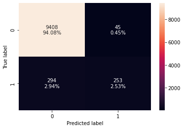

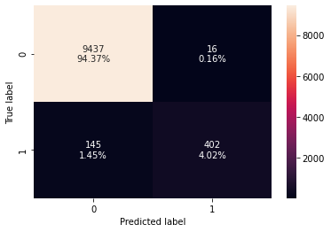

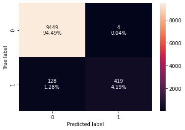

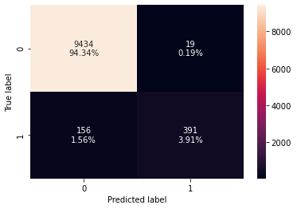

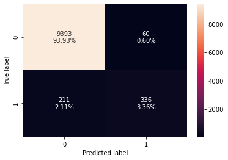

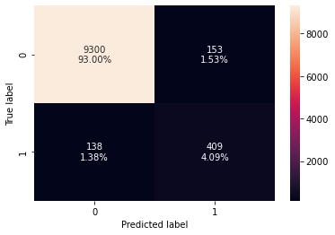

```python
# creating confusion matrix
for name, model in models:
    print("{}:\n".format(name, confusion_matrix_sklearn(model, X_val, y_val)))
    # confusion_matrix_sklearn(model, X_val, y_val)
```

**Observations**

## Model Building with Oversampled data

```python
print("Before UpSampling, counts of label 'Yes': {}".format(sum(y_train == 1)))
print("Before UpSampling, counts of label 'No': {} \n".format(sum(y_train == 0)))

# Synthetic Minority Over Sampling Technique
sm = SMOTE(sampling_strategy=1, k_neighbors=5, random_state=1)
X_train_over, y_train_over = sm.fit_resample(X_train, y_train)

print("After UpSampling, counts of label 'Yes': {}".format(sum(y_train_over == 1)))
print("After UpSampling, counts of label 'No': {} \n".format(sum(y_train_over == 0)))


print("After UpSampling, the shape of train_X: {}".format(X_train_over.shape))
print("After UpSampling, the shape of train_y: {} \n".format(y_train_over.shape))
```

```
Before UpSampling, counts of label 'Yes': 1640
Before UpSampling, counts of label 'No': 28360

After UpSampling, counts of label 'Yes': 28360
After UpSampling, counts of label 'No': 28360

After UpSampling, the shape of train_X: (56720, 40)
After UpSampling, the shape of train_y: (56720,)
```

**Let's evaluate the model performance by using KFold and cross_val_score**

```python
models_over = []  # Empty list to store all the models

# Appending models into the list
models_over.append(("lr_over", LogisticRegression(random_state=1)))
models_over.append(("Bagging_over", BaggingClassifier(random_state=1)))
models_over.append(("Random forest_over", RandomForestClassifier(random_state=1)))
models_over.append(("GBM_over", GradientBoostingClassifier(random_state=1)))
models_over.append(("Adaboost_over", AdaBoostClassifier(random_state=1)))
models_over.append(("dtree_over", DecisionTreeClassifier(random_state=1)))

results_over = []  # Empty list to store all model's CV scores
names_over = []  # Empty list to store name of the models


# loop through all models to get the mean cross validated score
print("\n" "Cross-Validation Performance:" "\n")

for name, model in models_over:
    scoring = scorer
    kfold = StratifiedKFold(
        n_splits=5, shuffle=True, random_state=1
    )  # Setting number of splits equal to 5
    cv_result_over = cross_val_score(
        estimator=model, X=X_train_over, y=y_train_over, scoring=scoring, cv=kfold
    )
    results_over.append(cv_result_over)
    names_over.append(name)
    print("{}: {}".format(name, cv_result_over.mean() * 100))

print("\n" "Training Performance:" "\n")

for name, model in models_over:
    model.fit(X_train_over, y_train_over)
    scores = Minimum_Vs_Model_cost(y_train_over, model.predict(X_train_over)) * 100
    print("{}: {}".format(name, scores))
```

```
Cross-Validation Performance:

lr_over: 80.0088377103361
Bagging_over: 95.40942899036293
Random forest_over: 96.92752086101537
GBM_over: 86.76274431000867
Adaboost_over: 82.87444544309412
dtree_over: 94.13857336531703

Training Performance:

lr_over: 80.02182071274724
Bagging_over: 99.69884106542297
Random forest_over: 100.0
GBM_over: 86.83582028618669
Adaboost_over: 82.97897241836695
dtree_over: 100.0
```

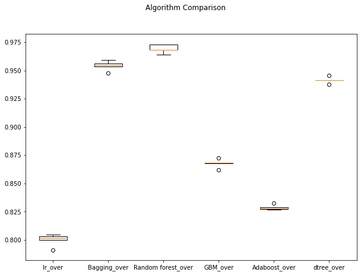

```python
# Plotting boxplots for CV scores of all models defined above
fig = plt.figure(figsize=(10, 7))

fig.suptitle("Algorithm Comparison")
ax = fig.add_subplot(111)

plt.boxplot(results_over)
ax.set_xticklabels(names_over)

plt.show()
```

```python
# Calculating different metrics on train set
print("Training performance:")
for name, model in models_over:
    over_train_perf = model_performance_classification_sklearn(
        model, X_train_over, y_train_over
    )
    over_train_perf
    print("{}:\n {}".format(name, over_train_perf))
```

```
Training performance:
lr_over:
    Accuracy  Recall  Precision    F1  Minimum_Vs_Model_cost
0     0.874   0.876      0.874 0.875                  0.800
Bagging_over:
    Accuracy  Recall  Precision    F1  Minimum_Vs_Model_cost
0     0.999   0.998      1.000 0.999                  0.997
Random forest_over:
    Accuracy  Recall  Precision    F1  Minimum_Vs_Model_cost
0     1.000   1.000      1.000 1.000                  1.000
GBM_over:
    Accuracy  Recall  Precision    F1  Minimum_Vs_Model_cost
0     0.944   0.914      0.971 0.942                  0.868
Adaboost_over:
    Accuracy  Recall  Precision    F1  Minimum_Vs_Model_cost
0     0.905   0.894      0.914 0.904                  0.830
dtree_over:
    Accuracy  Recall  Precision    F1  Minimum_Vs_Model_cost
0     1.000   1.000      1.000 1.000                  1.000
```

```python
# Calculating different metrics on validation set
print("validation performance:")
for name, model in models_over:
    over_val_perf = model_performance_classification_sklearn(model, X_val, y_val)
    over_val_perf
    print("{}:\n {}".format(name, over_val_perf))
```

```
validation performance:
lr_over:
    Accuracy  Recall  Precision    F1  Minimum_Vs_Model_cost
0     0.873   0.839      0.279 0.419                  0.503
Bagging_over:
    Accuracy  Recall  Precision    F1  Minimum_Vs_Model_cost
0     0.984   0.835      0.866 0.850                  0.759
Random forest_over:
    Accuracy  Recall  Precision    F1  Minimum_Vs_Model_cost
0     0.991   0.868      0.962 0.913                  0.812
GBM_over:
    Accuracy  Recall  Precision    F1  Minimum_Vs_Model_cost
0     0.966   0.881      0.636 0.739                  0.732
Adaboost_over:
    Accuracy  Recall  Precision    F1  Minimum_Vs_Model_cost
0     0.905   0.850      0.350 0.496                  0.563
dtree_over:
    Accuracy  Recall  Precision    F1  Minimum_Vs_Model_cost
0     0.951   0.814      0.535 0.645                  0.647
```

```
lr_over:

Bagging_over:

Random forest_over:

GBM_over:

Adaboost_over:

dtree_over:
```

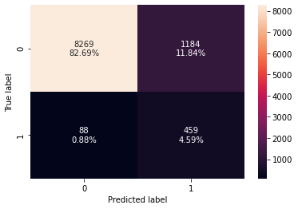

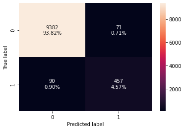

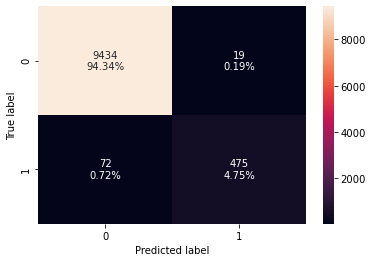

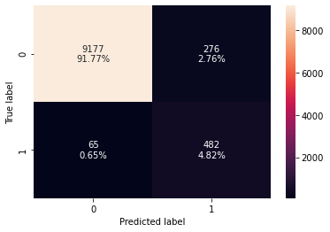

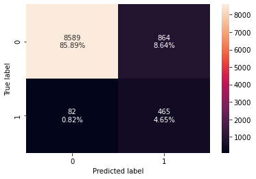

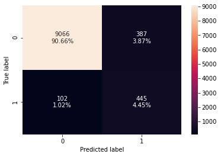

```python
# creating confusion matrix
for name, model in models_over:
    print("{}:\n".format(name, confusion_matrix_sklearn(model, X_val, y_val)))
    # confusion_matrix_sklearn(model, X_val, y_val)
```

**Observations**

## Model Building with Undersampled data

```python
# Random undersampler for under sampling the data
rus = RandomUnderSampler(random_state=1, sampling_strategy=1)
X_train_under, y_train_under = rus.fit_resample(X_train, y_train)
```

```python
print("Before Undersampling, counts of label 'Yes': {}".format(sum(y_train == 1)))
print("Before Undersampling, counts of label 'No': {} \n".format(sum(y_train == 0)))

print("After Undersampling, counts of label 'Yes': {}".format(sum(y_train_under == 1)))
print(
    "After Undersampling, counts of label 'No': {} \n".format(sum(y_train_under == 0))
)

print("After Undersampling, the shape of train_X: {}".format(X_train_under.shape))
print("After Undersampling, the shape of train_y: {} \n".format(y_train_under.shape))
```

```
Before Undersampling, counts of label 'Yes': 1640
Before Undersampling, counts of label 'No': 28360

After Undersampling, counts of label 'Yes': 1640
After Undersampling, counts of label 'No': 1640

After Undersampling, the shape of train_X: (3280, 40)
After Undersampling, the shape of train_y: (3280,)
```

**Let's evaluate the model performance by using KFold and cross_val_score**

```python
models_under = []  # Empty list to store all the models

# Appending models into the list
models_under.append(("lr_under", LogisticRegression(random_state=1)))
models_under.append(("Bagging_under", BaggingClassifier(random_state=1)))
models_under.append(("Random forest_under", RandomForestClassifier(random_state=1)))
models_under.append(("GBM_under", GradientBoostingClassifier(random_state=1)))
models_under.append(("Adaboost_under", AdaBoostClassifier(random_state=1)))
models_under.append(("dtree_under", DecisionTreeClassifier(random_state=1)))

results_under = []  # Empty list to store all model's CV scores
names_under = []  # Empty list to store name of the models


# loop through all models to get the mean cross validated score
print("\n" "Cross-Validation Performance:" "\n")

for name, model in models_under:
    scoring = scorer
    kfold = StratifiedKFold(
        n_splits=5, shuffle=True, random_state=1
    )  # Setting number of splits equal to 5
    cv_result_under = cross_val_score(
        estimator=model, X=X_train_under, y=y_train_under, scoring=scoring, cv=kfold
    )
    results_under.append(cv_result_under)
    names_under.append(name)
    print("{}: {}".format(name, cv_result_under.mean() * 100))

print("\n" "Training Performance:" "\n")

for name, model in models_under:
    model.fit(X_train_under, y_train_under)
    scores = Minimum_Vs_Model_cost(y_train_under, model.predict(X_train_under)) * 100
    print("{}: {}".format(name, scores))
```

```
Cross-Validation Performance:

lr_under: 77.65522788135344
Bagging_under: 81.69551921903387
Random forest_under: 84.67413072888996
GBM_under: 82.88956467253165
Adaboost_under: 80.05315674951575
dtree_under: 77.45754336793459

Training Performance:

lr_under: 77.73739927318691
Bagging_under: 96.69811320754717
Random forest_under: 100.0
GBM_under: 87.65366114377339
Adaboost_under: 83.05199189736663
dtree_under: 100.0
```

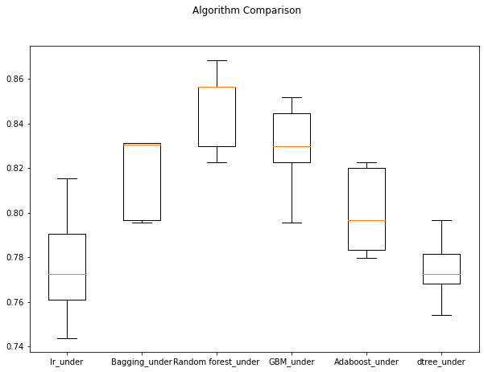

```python
# Plotting boxplots for CV scores of all models defined above
fig = plt.figure(figsize=(10, 7))

fig.suptitle("Algorithm Comparison")
ax = fig.add_subplot(111)

plt.boxplot(results_under)
ax.set_xticklabels(names_under)

plt.show()
```

```python
# Calculating different metrics on train set
print("Training performance:")
for name, model in models_under:
    under_train_perf = model_performance_classification_sklearn(
        model, X_train_under, y_train_under
    )
    over_train_perf
    print("{}:\n {}".format(name, under_train_perf))
```

```
Training performance:
lr_under:
    Accuracy  Recall  Precision    F1  Minimum_Vs_Model_cost
0     0.859   0.855      0.862 0.859                  0.777
Bagging_under:
    Accuracy  Recall  Precision    F1  Minimum_Vs_Model_cost
0     0.989   0.980      0.998 0.989                  0.967
Random forest_under:
    Accuracy  Recall  Precision    F1  Minimum_Vs_Model_cost
0     1.000   1.000      1.000 1.000                  1.000
GBM_under:
    Accuracy  Recall  Precision    F1  Minimum_Vs_Model_cost
0     0.952   0.918      0.985 0.950                  0.877
Adaboost_under:
    Accuracy  Recall  Precision    F1  Minimum_Vs_Model_cost
0     0.906   0.894      0.916 0.905                  0.831
dtree_under:
    Accuracy  Recall  Precision    F1  Minimum_Vs_Model_cost
0     1.000   1.000      1.000 1.000                  1.000
```

```python
# Calculating different metrics on validation set
print("validation performance:")
for name, model in models_under:
    under_val_perf = model_performance_classification_sklearn(model, X_val, y_val)
    under_val_perf
    print("{}:\n {}".format(name, under_val_perf))
```

```
validation performance:
lr_under:
    Accuracy  Recall  Precision    F1  Minimum_Vs_Model_cost
0     0.864   0.846      0.266 0.405                  0.492
Bagging_under:
    Accuracy  Recall  Precision    F1  Minimum_Vs_Model_cost
0     0.951   0.863      0.529 0.656                  0.674
Random forest_under:
    Accuracy  Recall  Precision    F1  Minimum_Vs_Model_cost
0     0.966   0.885      0.639 0.742                  0.736
GBM_under:
    Accuracy  Recall  Precision    F1  Minimum_Vs_Model_cost
0     0.951   0.888      0.533 0.666                  0.692
Adaboost_under:
    Accuracy  Recall  Precision    F1  Minimum_Vs_Model_cost
0     0.880   0.865      0.295 0.440                  0.523
dtree_under:
    Accuracy  Recall  Precision    F1  Minimum_Vs_Model_cost
0     0.866   0.854      0.271 0.411                  0.498
```

```
lr_under:

Bagging_under:

Random forest_under:

GBM_under:

Adaboost_under:

dtree_under:
```

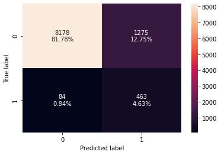

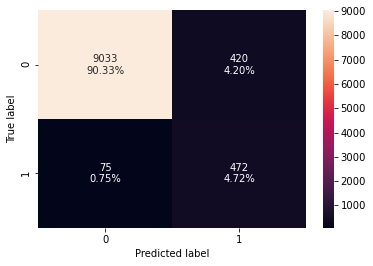

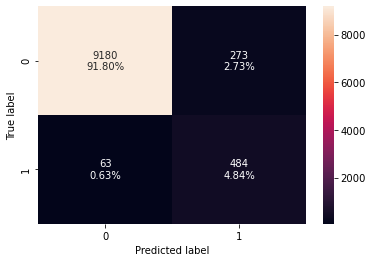

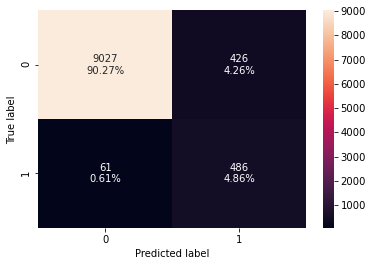

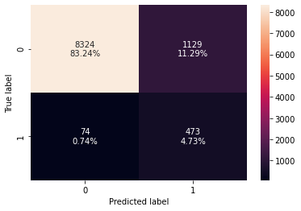

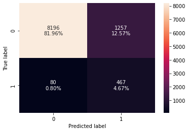

```python
# creating confusion matrix
for name, model in models_under:
    print("{}:\n".format(name, confusion_matrix_sklearn(model, X_val, y_val)))
    # confusion_matrix_sklearn(model, X_val, y_val)
```

**Observations**

- As per CV score GBM and Randomforest have high scores.
- Only Random forest is showing high metric scores but it seems a bit overfitting.

## Model Selection

Comapring the Original Data, Oversampled data and Undersampled data, I am selecting the below three models for HyperTuning:

- Random forest_Over
- Bagging_over
- GBM_over

## HyperparameterTuning

### RandomizedSearchCV

**Tuning the given three models using RandomizedSearchCV**

### Bagging_over

```python
%%time

# defining model
model = BaggingClassifier(random_state=1)

# Parameter grid to pass in GridSearchCV

param_grid = { 'max_samples': [0.8,0.9], 'max_features': [0.8,0.9], 'n_estimators' : [40,50]}

# Type of scoring used to compare parameter combinations
#scorer = metrics.make_scorer(metrics.recall_score)
scorer = metrics.make_scorer(Minimum_Vs_Model_cost, greater_is_better=True)


#Calling RandomizedSearchCV
randomized_cv = RandomizedSearchCV(estimator=model, param_distributions=param_grid, n_jobs = -1, n_iter=50, scoring=scorer, cv=5, random_state=1)

#Fitting parameters in RandomizedSearchCV
randomized_cv.fit(X_train_over,y_train_over)

print("Best parameters are {} with CV score={}:" .format(randomized_cv.best_params_,randomized_cv.best_score_))
```

```
Best parameters are {'n_estimators': 50, 'max_samples': 0.9, 'max_features': 0.9} with CV score=0.9643813640959931:
Wall time: 46min 41s
```

```python
# building model with best parameters
Bagging_tuned = BaggingClassifier(n_estimators=50, max_samples=0.9, max_features=0.9,)
# Fit the model on training data
Bagging_tuned.fit(X_train_over, y_train_over)
```

```
BaggingClassifier(max_features=0.9, max_samples=0.9, n_estimators=50)
```

```python
# Calculating different metrics on train set
Bagging_random_train = model_performance_classification_sklearn(
    Bagging_tuned, X_train_over, y_train_over
)
print("Training performance:")
Bagging_random_train
```

```
Training performance:
```

|  | Accuracy | Recall | Precision | F1 | Minimum_Vs_Model_cost |
| --- | --- | --- | --- | --- | --- |
| 0 | 1.000 | 1.000 | 1.000 | 1.000 | 1.000 |

```python
# Calculating different metrics on validation set
Bagging_random_val = model_performance_classification_sklearn(
    Bagging_tuned, X_val, y_val
)
print("Validation performance:")
Bagging_random_val
```

```
Validation performance:
```

|  | Accuracy | Recall | Precision | F1 | Minimum_Vs_Model_cost |
| --- | --- | --- | --- | --- | --- |
| 0 | 0.987 | 0.854 | 0.898 | 0.875 | 0.784 |

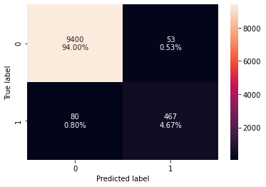

```python
# creating confusion matrix
confusion_matrix_sklearn(Bagging_tuned, X_val, y_val)
```

**Observations**

- The CV has increased a bit to 0.96
- The metrics scores have improved in validation
- The training data seems overfitting.

### Random forest_over

```python
%%time

# defining model
model = RandomForestClassifier(random_state=1)

# Parameter grid to pass in GridSearchCV

param_grid = { "n_estimators": [150,250], "min_samples_leaf": np.arange(1, 3), "max_features": ['sqrt','log2'], "max_samples": np.arange(0.2, 0.6, 0.1)}

# Type of scoring used to compare parameter combinations
#scorer = metrics.make_scorer(metrics.recall_score)
scorer = metrics.make_scorer(Minimum_Vs_Model_cost, greater_is_better=True)


#Calling RandomizedSearchCV
randomized_cv = RandomizedSearchCV(estimator=model, param_distributions=param_grid, n_jobs = -1, n_iter=50, scoring=scorer, cv=5, random_state=1)

#Fitting parameters in RandomizedSearchCV
randomized_cv.fit(X_train_over,y_train_over)

print("Best parameters are {} with CV score={}:" .format(randomized_cv.best_params_,randomized_cv.best_score_))
```

```
Best parameters are {'n_estimators': 250, 'min_samples_leaf': 1, 'max_samples': 0.5000000000000001, 'max_features': 'sqrt'} with CV score=0.9588968858404104:
Wall time: 35min 58s
```

```python
# building model with best parameters
Random_tuned = RandomForestClassifier(
    n_estimators=250, min_samples_leaf=1, max_samples=0.50, max_features="sqrt",
)
# Fit the model on training data
Random_tuned.fit(X_train_over, y_train_over)
```

```
RandomForestClassifier(max_features='sqrt', max_samples=0.5, n_estimators=250)
```

```python
# Calculating different metrics on train set
Random_random_train = model_performance_classification_sklearn(
    Random_tuned, X_train_over, y_train_over
)
print("Training performance:")
Random_random_train
```

```
Training performance:
```

|  | Accuracy | Recall | Precision | F1 | Minimum_Vs_Model_cost |
| --- | --- | --- | --- | --- | --- |
| 0 | 0.999 | 0.998 | 1.000 | 0.999 | 0.996 |

```python
# Calculating different metrics on validation set
Random_random_val = model_performance_classification_sklearn(Random_tuned, X_val, y_val)
print("Validation performance:")
Random_random_val
```

```
Validation performance:
```

|  | Accuracy | Recall | Precision | F1 | Minimum_Vs_Model_cost |
| --- | --- | --- | --- | --- | --- |
| 0 | 0.990 | 0.872 | 0.946 | 0.908 | 0.813 |

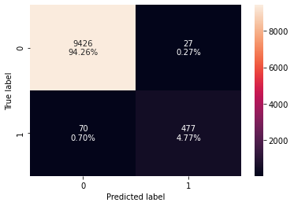

```python
# creating confusion matrix
confusion_matrix_sklearn(Random_tuned, X_val, y_val)
```

**Observations**

- Overfitting has reduced.
- CV score is almost the same ~0.96